# Analyzing “Brand Ticker” data.

flovv

[The Brand Ticker](http://www.thebrandticker.com) provides brand specific marketing data. On a day to day basis they list the brand value and top 3 associations gathered from news mentions and social data. They provide no documentation on how they process the data or which sources they use.

Here is short look at their service. I pulled half a year’s data in irregular intervalls from their API using a small r-script. See this [GIST](https://gist.github.com/flovv/30a74925958908372e98)

Due to some recent attention we start the analysis by looking at the Volkswagen (VW) data.

```
##    attr_1 attr_1_flag      attr_2 attr_2_flag   attr_3 attr_3_flag
## 25  liked       green complicated         red advanced       green
## 26  faked         red   polluting         red  secured       green
## 27  liked       green complicated         red advanced       green
## 28  faked         red   polluting         red  secured       green
## 29  faked         red   polluting         red  secured       green
## 30  faked         red   polluting         red  secured       green
##      change    value         brand brandId       Date
## 25 2.957404 5109.233 Volkswagen VW     439 2015-11-25
## 26 3.678028 5389.976 Volkswagen VW     439 2015-11-27
## 27 7.359091 6147.744 Volkswagen VW     439 2015-12-02
## 28 7.359091 6147.744 Volkswagen VW     439 2015-12-02
## 29 2.977252 6574.628 Volkswagen VW     439 2015-12-08
## 30 2.977252 6574.628 Volkswagen VW     439 2015-12-08
```

The first 6 columns are the brand associations, gathered from news data, or a survey (who knows…?). It’s helpful that the flag attributes already labels the associations as positiv/negativ (red or green). The value column is the so-called “Brand Value”.

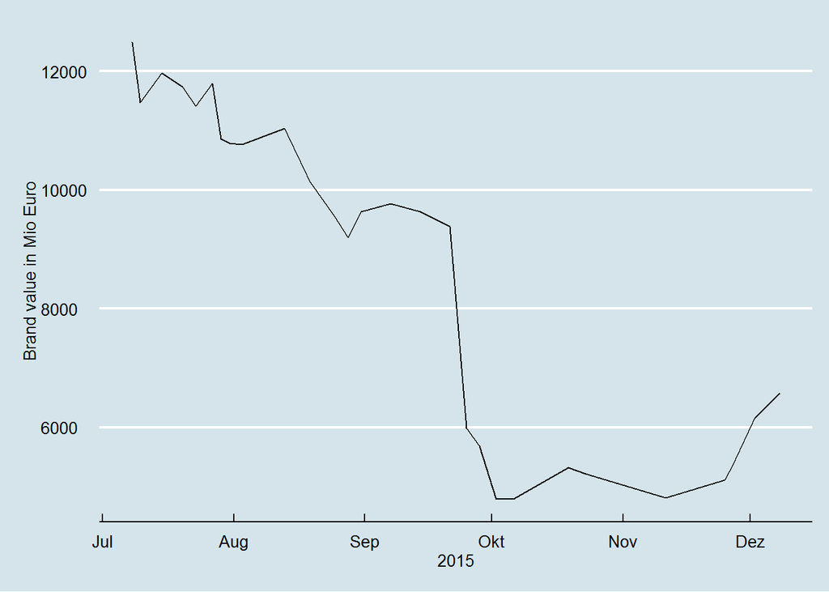

In order to see if the brand value is related to associations, I color-code the brand value with the top (attr_1) association.

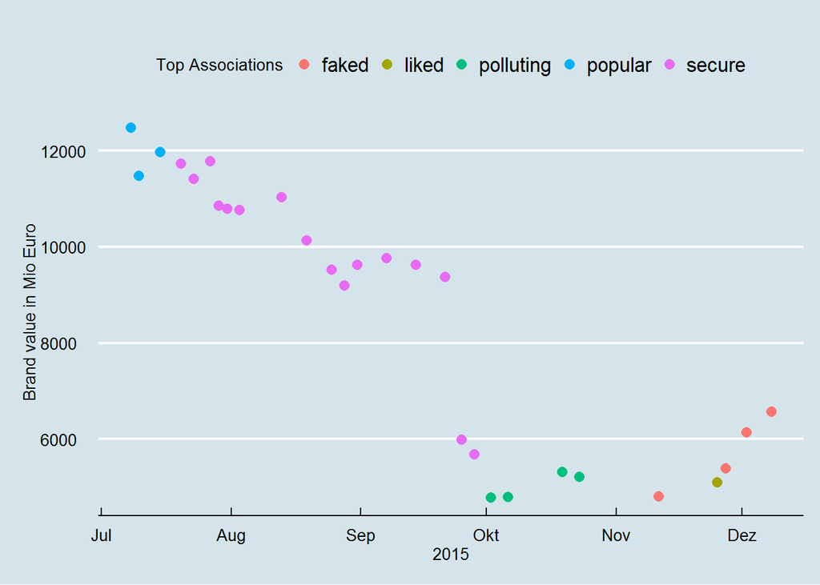

For the diesel-gate event, we see that the top association is a rather lagging than predicting variable. The brand value massively drops, the association remains “secure”. The association change from “secure” to “polluting” happens with a distinct lag. In order to visualize the second and third association, we can use a simple histogram of mentions in the data set.

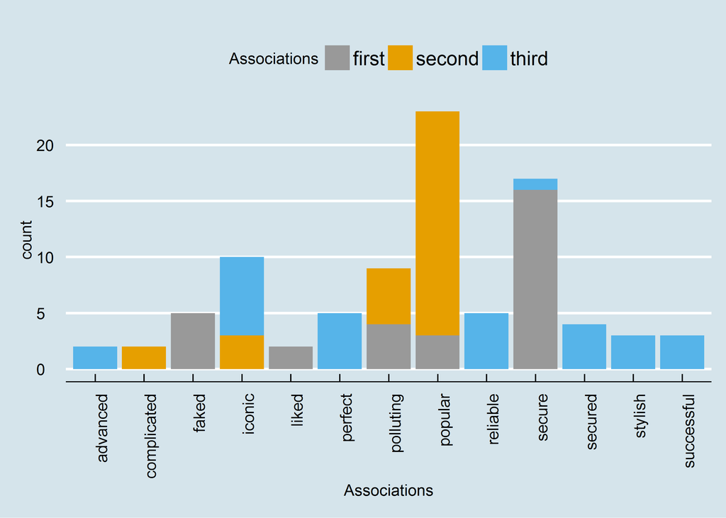

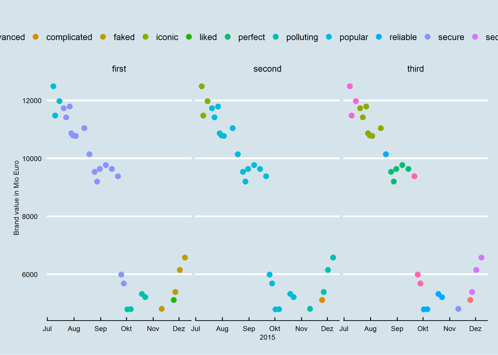

In order to unterstand the brand value variable it bit better, I scraped VW’s stock market data from Yahoo. See this [GIST](https://gist.github.com/flovv/50ed4495911576040e34)

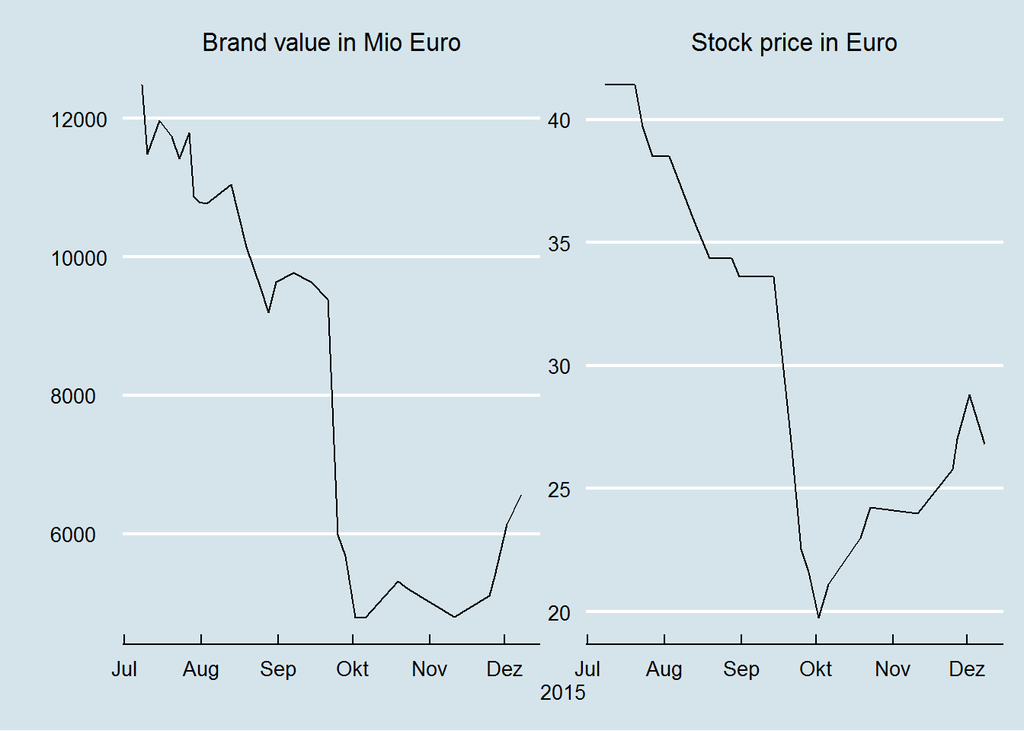

Apparently brand value is just a linear function of stock market data and can be regarded as more or less identical.

**Brandtickers Brand value has a direct relation to VW’s stock price**

|  | *Dependent variable:* |  |
| --- | --- | --- |
|  | value |  |
|  | (1) | (2) |
| Close | 365.498*** | 273.071*** |
|  | (22.435) | (6.069) |
| Constant | -3,057.386*** |  |
|  | (724.722) |  |
| Observations | 30 | 30 |
| R<sup>2</sup> | 0.905 | 0.986 |
| Adjusted R<sup>2</sup> | 0.901 | 0.985 |
| Residual Std. Error | 854.555 (df = 28) | 1,073.895 (df = 29) |
| F Statistic | 265.414*** (df = 1; 28) | 2,024.172*** (df = 1; 29) |
| *Note:* | p<0.1; p<0.05; p<0.01 |  |

I find it quite misleading to speak of “Brand Value” and taking stock market data as a reference. Plenty of factors (economic condictions, production costs, …) have an impact on stock prices, while the value of a brand is related to subjective perceptions.